# Bayesian Project Report

#### 7. Rsults for parameters

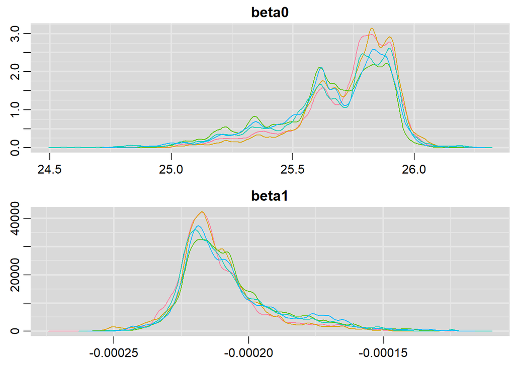

Standard Model (2012).

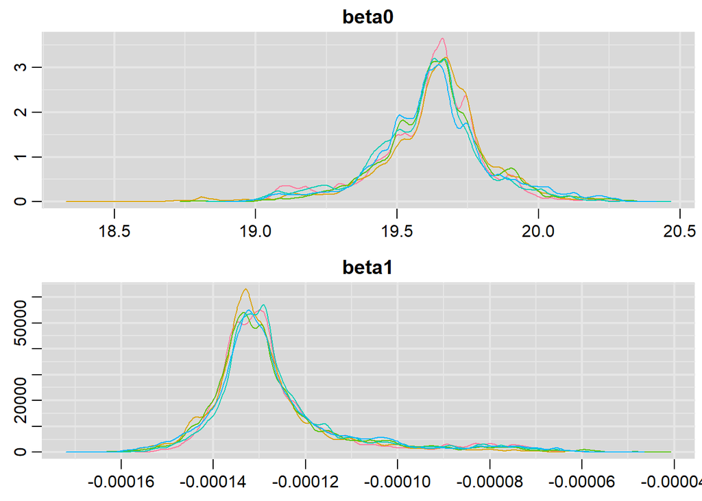

Standard Model (2022).

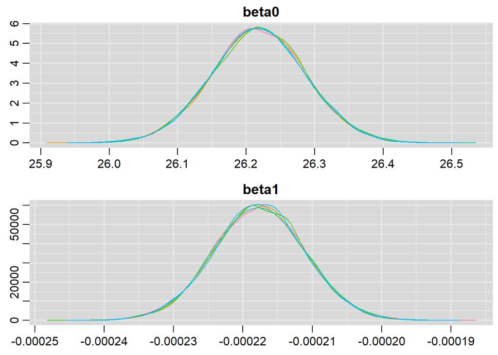

Global-local Model (2012).

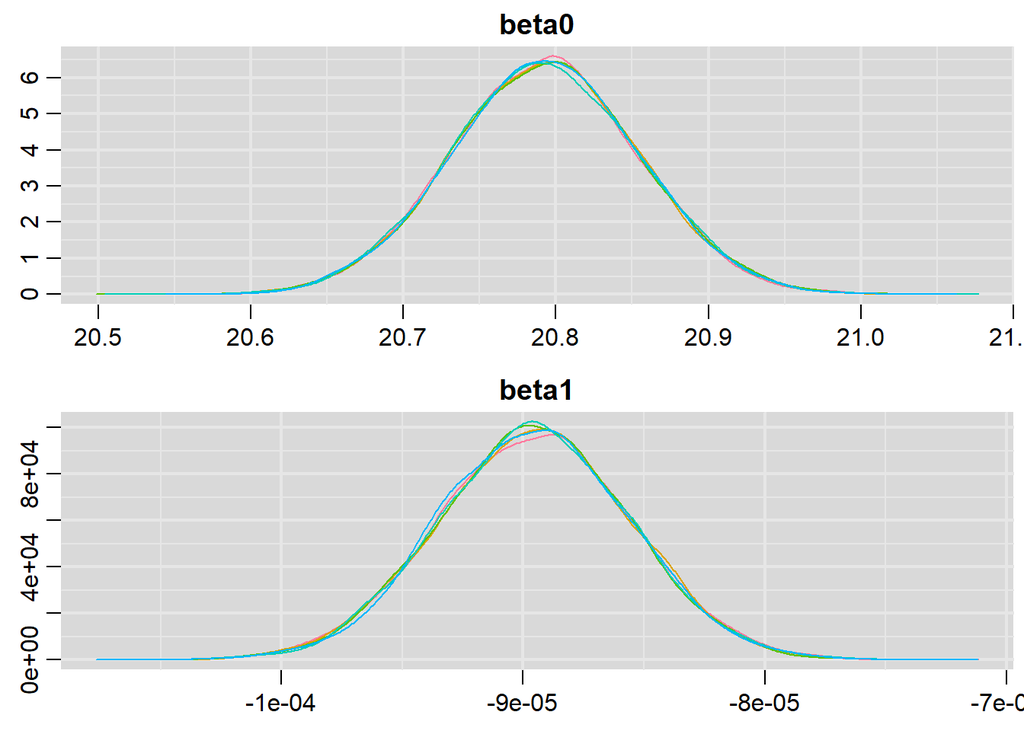

Global-local Model (2022).

Posterior density of $\beta_0$ and $\beta_1$ by the model without global-local priors.

```
    In 2012, $95\%$ CI for $\beta_0$ is (25.16, 25.97), $95\%$ CI for $\beta_1$ is (-0.000234, -0.000163).

    In 2022, $95\%$ CI for $\beta_0$ is (19.15, 20.02), $95\%$ CI for $\beta_1$ is (-0.000147, -0.000080).
```

Posterior density of $\beta_0$ and $\beta_1$ by the global-local model.

```
    In 2012, $95\%$ CI for $\beta_0$ is (26.08, 26.35), $95\%$ CI for $\beta_1$ is (-0.000231, -0.000205).

    In 2022, $95\%$ CI for $\beta_0$ is (20.67, 20.91), $95\%$ CI for $\beta_1$ is (-9.7e-05,-8.2e-05).
```

#### 8. Remarks

In 2022, the percentage of uninsured individuals shows a general decrease compared to a decade ago.

The global-local model is more informative than the standard model without global-local priors.

#### 9. Conclusions

The global-local model incorporates flexible shrinkage, which improves uncertainty quantification and demonstrates more robust parameter estimation.

The model without global-local priors tends to exhibit higher sensitivity to noise and lacks the adaptive regularization provided by the global-local approach. As a result, it may lead to overfitting or underestimating variability in the data.

#### 10. References

[1] Bhadra A, Datta J, Polson N, and Willard B. (2019). Lasso meets horseshoe: a survey. Statistical Science, 34(3), 405–427. https://www.jstor.org/stable/26874188.

[2] Cahoy, D., & Sedransk, J. (2024). Improved Small Area Inference from Data Integration Using Global-Local Priors. arXiv preprint arXiv:2412.07824. Retrieved from https://arxiv.org/abs/2412.07824.

[3] Cahoy, D., and Sedransk, J. (2023). Combining data from surveys and related sources. Survey Methodology, Statistics Canada, Catalogue No. 12-001-X, Vol. 49, No. 1. Retrieved from http://www.statcan.gc.ca/pub/12-001-x/2023001/article/00003-eng.htm.

[4] Kevin Davis Ross. (2025). Bayesian Reasoning and Methods. Retrieved from https://bookdown.org/kevin_davisross/bayesian-reasoning-and-methods/regression.html.

[5]Polson N and Scott J. (2012). On the half-Cauchy prior for a global scale parameter. Bayesian Analysis, 7, 887- 902.

[6] U.S. Census Bureau. (2025). Small Area Health Insurance Estimates (SAHIE) Program. Retrieved from https://www.census.gov/programs-surveys/sahie.html.